# Null models for GoM model fit

Kushal K Dey

March 14, 2016

```r
library(CountClust)
library(picante)
```

## Overview

The null models are an useful and widely used technique to test for the randomization of ecological presenece absence data. We apply a similar mechanism now for the GoM model fits.

```r
data=read.csv("../external_data/Himalayan_grid_matrix.csv",header=TRUE);
counts=as.matrix(data[,-1]);
rownames(counts)=data[,1];
new_data1 <- data.frame(read.csv('../external_data/MohanGrids.csv'));
new_data2 <- data.frame(read.csv('../external_data/MohanGrids2.csv'));
bird_species <- union(as.vector(colnames(counts)), union(as.vector(new_data1[,1]), as.vector(new_data2[,1])));
new_data <- matrix(0,dim(counts)[1]+3,length(bird_species));
new_data[1,match(new_data1[,1],bird_species)]=new_data1[,2];
new_data[2,match(new_data1[,1],bird_species)]=new_data1[,3];
new_data[3,match(new_data2[,1],bird_species)]=new_data2[,2];
new_data[4:(dim(counts)[1]+3),match(colnames(counts),bird_species)]=counts;
new_counts <- as.matrix(new_data);
rownames(new_counts) <- c(c("U1","U2","MA1"),rownames(counts));
colnames(new_counts) <- bird_species;
new_counts <- new_counts[-(1:3),];
```

We load the metadata

```r
metadata=read.csv("../external_data/Himalayan_grid_metadata.csv",header=TRUE);
elevation_metadata=metadata$Elevation;

east_west_dir = metadata$WorE;
```

We use the `randomizeMatrix()` function due to the package `picante` for applying null models and testing for the efficcacy of the clustering we use.

## GoM model fit (maptpx) - original data

```r
topics_clus <- FitGoM(new_counts, K=2, tol=0.1);
```

```
## Fitting the topic model (due to Matt Taddy)
```

```
##
## Estimating on a 35 document collection.
## Fitting the 2 topic model.
## log posterior increase: 281.4, 0.1, 1, 48.3, 0.1, done.
```

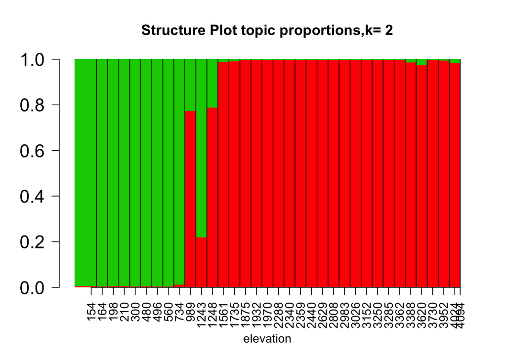

```r
K <- 2
barplot(t(topics_clus[[1]]$omega[order(elevation_metadata),]),col=2:(K+1),axisnames=F,space=0,border=NA,main="",las=1,ylim=c(0,1),cex.axis=1.5,cex.main=1.4, xlab="elevation")
title(main=paste("Structure Plot topic proportions,k=",K))
combo_patch_dir = paste0(round(elevation_metadata));
combo_patch_dir_ordered = combo_patch_dir[order(elevation_metadata)];

match_labs=match(unique(combo_patch_dir_ordered),combo_patch_dir_ordered);
match_labs_suffix=c(match_labs[2:length(unique(combo_patch_dir_ordered))],35);
match_labs_prefix=match_labs[1:(length(unique(combo_patch_dir_ordered)))];
labs=match_labs_prefix + 0.5*(match_labs_suffix - match_labs_prefix);

axis(1,at=labs,unique(combo_patch_dir_ordered),las=2);
abline(v=match_labs[2:length(match_labs)]);
```

## Randomized data + maptpx fit (K=2)

```r
null_counts <- picante::randomizeMatrix(new_counts, null.model = "richness", iterations=1000);

topics_null <- FitGoM(null_counts, K=2, tol=0.1);
```

```
## Fitting the topic model (due to Matt Taddy)
```

```
##
## Estimating on a 35 document collection.
## Fitting the 2 topic model.
## log posterior increase: 131, 23.1, 16.4, 14, 17.3, done.
```

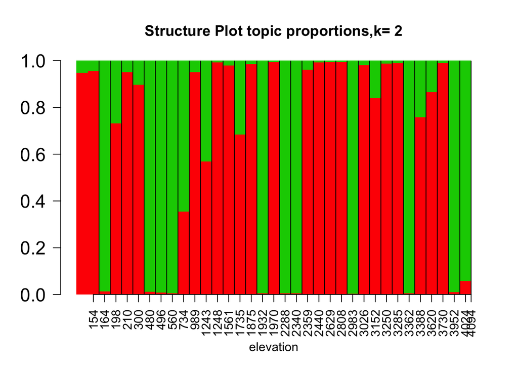

```r
K <- 2
barplot(t(topics_null[[1]]$omega[order(elevation_metadata),]),col=2:(K+1),axisnames=F,space=0,border=NA,main="",las=1,ylim=c(0,1),cex.axis=1.5,cex.main=1.4, xlab="elevation")
title(main=paste("Structure Plot topic proportions,k=",K))
combo_patch_dir = paste0(round(elevation_metadata));
combo_patch_dir_ordered = combo_patch_dir[order(elevation_metadata)];

match_labs=match(unique(combo_patch_dir_ordered),combo_patch_dir_ordered);
match_labs_suffix=c(match_labs[2:length(unique(combo_patch_dir_ordered))],35);
match_labs_prefix=match_labs[1:(length(unique(combo_patch_dir_ordered)))];
labs=match_labs_prefix + 0.5*(match_labs_suffix - match_labs_prefix);

axis(1,at=labs,unique(combo_patch_dir_ordered),las=2);
abline(v=match_labs[2:length(match_labs)]);
```

## Null model evaluation

We use the `nullmodel_GoM()` functionality in the CountClust package to obtain statistical measures of how much the observed counts matrix differs from null randomized matrices.

Under the default, we generate 100 randomized matrices and compare the observed matrix log Bayes factor with that of the randomized designs.

### Trialswap method

We first use the `trialswap` method.

```r
out <- nullmodel_GoM(new_counts, K=2, null.model = "trialswap")
```

[output not shown]

[output cut: 349 more lines]

```
## Estimating on a 35 document collection.
## Fitting the 2 topic model.
## log posterior increase: 276.5, 15.2, 68.8, 0.2, done.
##
## Estimating on a 35 document collection.
## Fitting the 2 topic model.
## log posterior increase: 276.2, done.
##
## Estimating on a 35 document collection.
## Fitting the 2 topic model.
## log posterior increase: 271.5, 1.1, 26.4, 0.6, done.
##
## Estimating on a 35 document collection.
## Fitting the 2 topic model.
## log posterior increase: 281.4, 0.1, 1, 48.3, 0.1, done.
```

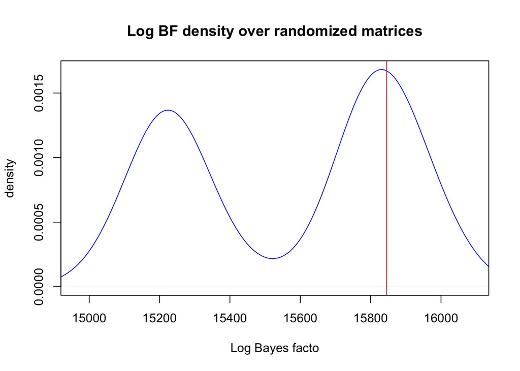

```r
print(out$pval)
```

```
## [1] 0.15
```

### Richness method

Then we use the `richness` method.

```r
out <- nullmodel_GoM(new_counts, K=2, null.model = "richness")
```

[output not shown]

[output cut: 349 more lines]

```
## Estimating on a 35 document collection.
## Fitting the 2 topic model.
## log posterior increase: 89.9, 61.2, 11.3, 11.2, 0.9, done.
##
## Estimating on a 35 document collection.
## Fitting the 2 topic model.
## log posterior increase: 146.1, 25, 24, 13.3, 5.7, 0.2, 0.2, 23, done.
##
## Estimating on a 35 document collection.
## Fitting the 2 topic model.
## log posterior increase: 174.3, 26.5, 1.9, 1.4, 12.4, 1.9, 7.2, 0.3, done.
##
## Estimating on a 35 document collection.
## Fitting the 2 topic model.
## log posterior increase: 281.4, 0.1, 1, 48.3, 0.1, done.
```

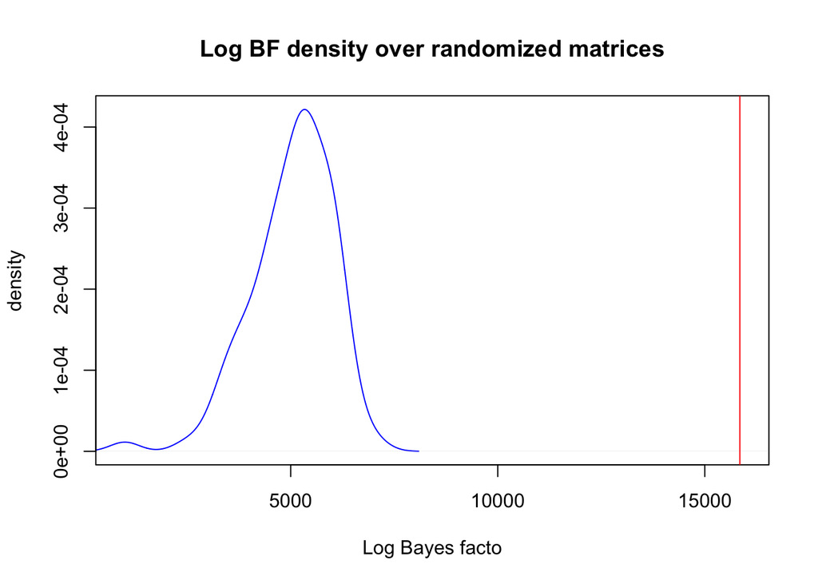

```r
print(out$pval)
```

```
## [1] 0
```

### Frequency method

Consider now the `frequency` method.

```r
out <- nullmodel_GoM(new_counts, K=2, null.model = "frequency")
```

[output not shown]

[output cut: 349 more lines]

```
## Estimating on a 35 document collection.
## Fitting the 2 topic model.
## log posterior increase: 41.8, 39.9, 34.2, 0.9, 0.5, 1.4, done.
##
## Estimating on a 35 document collection.
## Fitting the 2 topic model.
## log posterior increase: 69.8, 29.1, 28, 0.7, 0.6, 0.4, 13.2, 1.5, 1, done.
##
## Estimating on a 35 document collection.
## Fitting the 2 topic model.
## log posterior increase: 96.7, 92.1, 14.3, 5.7, 1.4, 4.6, 0.2, done.
##
## Estimating on a 35 document collection.
## Fitting the 2 topic model.
## log posterior increase: 281.4, 0.1, 1, 48.3, 0.1, done.
```

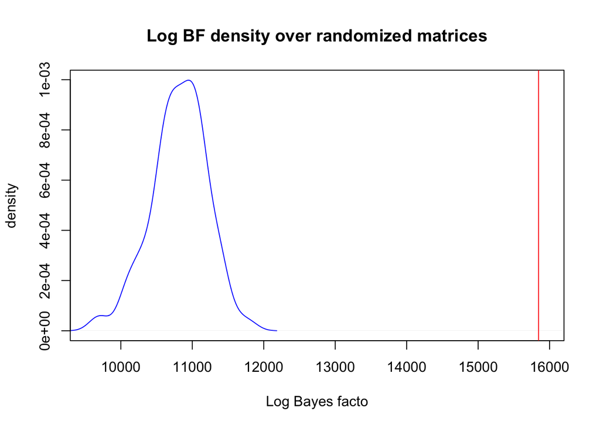

```r
print(out$pval)
```

```
## [1] 0
```

### Independent Swap method

Finally we consider the `independentswap` method.

```r
out <- nullmodel_GoM(new_counts, K=2, null.model = "independentswap")
```

[output not shown]

[output cut: 349 more lines]

```
## Estimating on a 35 document collection.
## Fitting the 2 topic model.
## log posterior increase: 62.1, 27.9, 9.4, 17, 1.8, 7.6, done.
##
## Estimating on a 35 document collection.
## Fitting the 2 topic model.
## log posterior increase: 67.7, 41.2, 18.8, 5, 0.5, 7.3, done.
##
## Estimating on a 35 document collection.
## Fitting the 2 topic model.
## log posterior increase: 92.2, 6, 8.3, 2.3, 2.7, 1.2, done.
##
## Estimating on a 35 document collection.
## Fitting the 2 topic model.
## log posterior increase: 281.4, 0.1, 1, 48.3, 0.1, done.
```

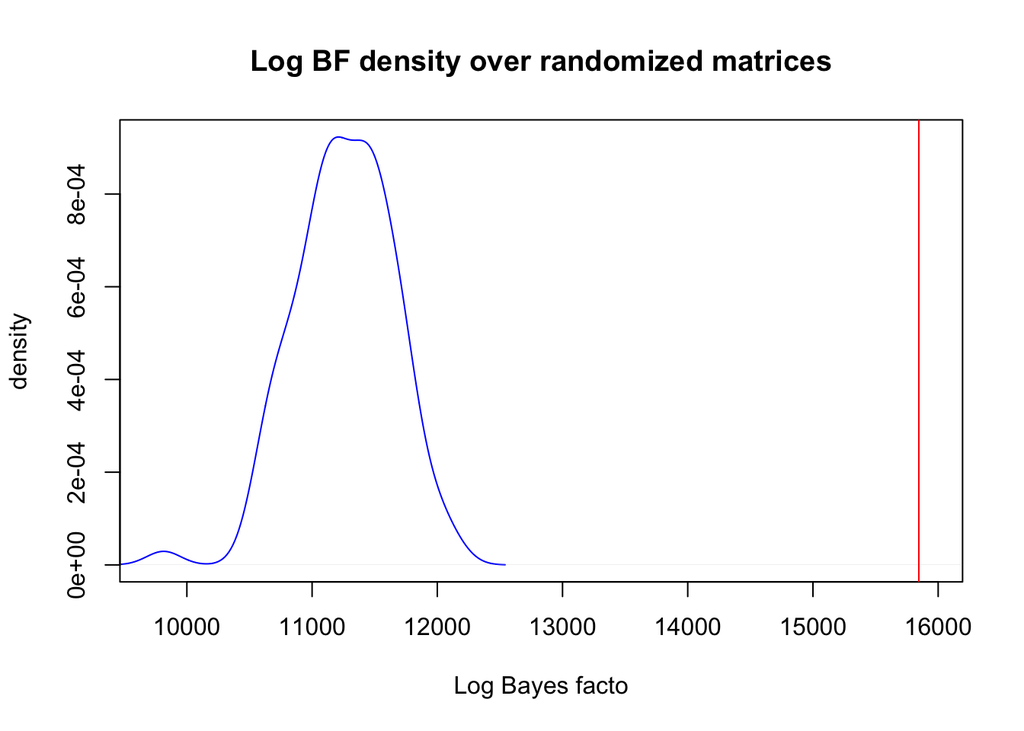

```r
print(out$pval)
```

```
## [1] 0
```